# Homework 12

Use only when explicitly invoked to explore clustering methods, select a model via label-free criteria, and write a concise statistical report.

## Question 1: Design and use an unsupervised-learning skill

Create a reusable skill that directs an AI agent to explore clustering methods, select one, and explain its results in a concise report. Use `data/golub.csv` from the combined ZIP to cluster the 38 biological samples using their 3,051 gene measurements. Each observation is one sample. Use `gene_1` through `gene_3051` as the gene-expression variables; `sample_id` identifies the sample, and `leukemia_type` gives its known class label.

1. **Define the skill.** Write a single `SKILL.md` file no larger than **5 KB (5,000 bytes)**, including YAML `name` and `description` frontmatter. Keep the skill independent of any particular dataset, variable names, or observed results. Provide the data details separately when invoking it, and configure it to load only when explicitly invoked.

   The skill must try **at least three different clustering algorithms**, such as K-means, hierarchical clustering, and spectral clustering. It should guide preprocessing, tuning, the choice of the number of clusters, and the criteria used to compare methods and select a final one. You may include dimension reduction, such as PCA or UMAP, but an embedding alone does not count as a clustering algorithm. Decide how the skill should present the selected clustering visually and interpret the main findings and limitations.

   **The skill must explicitly instruct the agent to limit its generated analysis report to one printed page, including all text, figures, and tables, and to present clustering results from only one selected method.** The report may briefly mention the other methods considered to justify the selection, but must not present their clustering results.
2. **Apply the skill.** Explicitly invoke it to analyze the Golub data and produce a clearly readable report of **no more than one printed page**. Use gene expression for fitting and method selection. If you use the known leukemia-type labels, use them only to interpret the final clustering.

   Briefly name the algorithms considered, explain the selection criteria, and justify the chosen method. **Present clustering results only for the selected algorithm**, including a meaningful visual presentation and an interpretation of the groups. Choose the figures or tables and the key evidence carefully so that the report makes effective use of the limited space.

## Data and selection

   The Golub data contain 38 leukemia samples and 3,051 gene measurements. To explore structure without using diagnoses, all gene predictors were standardized and reduced by PCA; clustering used the first 2, 5, or 10 PCs. With seed 43212, K-means, Ward hierarchical, and Gaussian spectral clustering were compared for 2 or 3 clusters; spectral graph bandwidth was also varied. Average silhouette was the primary selection criterion; resampling stability broke ties. Eight 30-sample refits assessed stability (adjusted Rand agreement with each full-data fit); minimum cluster size checks for tiny groups. Leukemia labels did not affect fitting or selection.

   **Show the workflow**

   ```r
   knitr::kable(
     cv_table, digits = 6,
     col.names = c("Algorithm", "Best setting", "Silhouette", "Smallest cluster", "Stability ARI", "Selected"),
     caption = "Best setting per method; select by silhouette, with stability as a tie-breaker/check."
   )
   ```

   Best setting per method; select by silhouette, with stability as a tie-breaker/check.

   | Algorithm | Best setting | Silhouette | Smallest cluster | Stability ARI | Selected |
   | --- | --- | --- | --- | --- | --- |
   | Spectral | k=3, PCs=2, sigma x 0.5 | 0.442706 | 10 | 0.802690 | Yes |
   | K-means | k=3, PCs=2 | 0.442706 | 10 | 0.602467 |  |
   | Ward | k=3, PCs=2 | 0.440386 | 8 | 0.679523 |  |

## Selected clustering

   **Spectral** (k=3, PCs=2, sigma x 0.5) was selected (silhouette 0.442706; smallest cluster 10; stability ARI 0.803). Only this model’s clustering is shown. PCA 1–2 display 25.0% of standardized expression variation; point shapes show diagnoses only for post-selection interpretation.

   **Show the workflow**

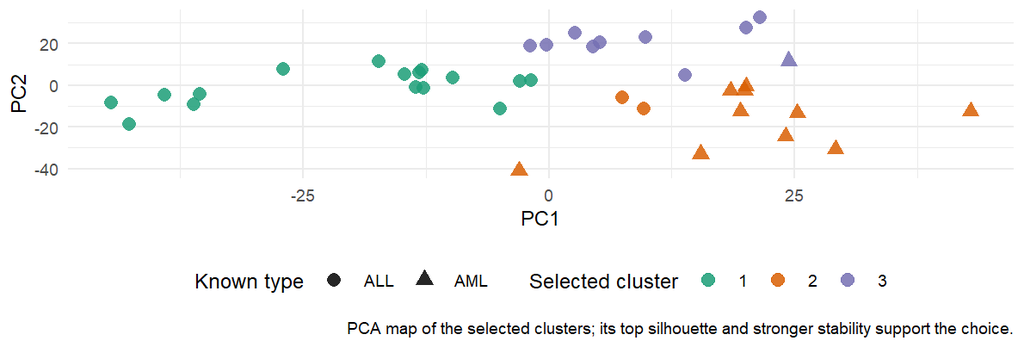

   ```r
   ggplot2::ggplot(plot_data, ggplot2::aes(
     x = PC1, y = PC2, color = Cluster, shape = Type
   )) +
     ggplot2::geom_point(size = 2.5, alpha = 0.85) +
     ggplot2::scale_color_brewer(palette = "Dark2") +
     ggplot2::labs(
       x = "PC1", y = "PC2", color = "Selected cluster", shape = "Known type",
       caption = "PCA map of the selected clusters; its top silhouette and stronger stability support the choice."
     ) +
     ggplot2::theme_minimal(base_size = 9) +
     ggplot2::theme(legend.position = "bottom",
                    plot.caption = ggplot2::element_text(size = 7))
   ```

   Cluster composition, examined only after selection:

   **Show the workflow**

   ```r
   knitr::kable(cluster_table, col.names = c("Cluster", "Samples", "ALL", "AML"))
   ```

   | Cluster | Samples | ALL | AML |
   | --- | --- | --- | --- |
   | 1 | 16 | 16 | 0 |
   | 2 | 12 | 2 | 10 |
   | 3 | 10 | 9 | 1 |

   The groups show 2 cluster(s) containing both leukemia types. Silhouette and stability are internal heuristics, not evidence that clusters are biologically real; results may change with the small sample, selected PCA dimension, and similarity graph. K-means and Ward were also compared, but their clustering results are not shown.
3. **Review and submit.** Check the analysis and its interpretation. Submit the report as a PDF named `homework-12.pdf` or a self-contained HTML file named `homework-12.html`, and the complete skill as `SKILL.md`, in `homework/week-12/`. Append the complete skill definition after the one-page analysis report; this appendix is outside the one-page limit.

# Unsupervised Learning

   Use this workflow only when the user explicitly invokes this skill and supplies the dataset and predictors. If labels are available, they must not be used for fitting or model selection; labels may be used after selection to interpret clusters. Do not assume variable names, class count, coding, or results. Ask for missing inputs before analysis. Use only clustering methods.

## Analysis Procedure

   1. Identify the predictors and any required coding. Check for missing/non-numeric predictors. Determine if the data are suitable for an unsupervised learning analysis. Scale the predictors if necessary.
   2. Set and report a random seed. If necessary, use dimension reduction via PCA or UMAP and explain why. If using UMAP, treat it as an optional embedding, not a clustering method, and don’t select a model from its plot alone.
   3. Select **at least three** **different clustering algorithms**, such as K-means, hierarchical clustering, and spectral clustering and explain why the algorithms were selected.
   4. Tune only the important settings for each clustering algorithm; for spectral clustering, compare the similarity-graph settings as well as the number of clusters.
   5. Compare candidates using a consistent label-free criterion, such as average silhouette, and check cluster sizes and stability.
   6. Select and justify one final model; do not use known class labels for tuning or selection.

## Report Requirements

   Create the analysis report as a Quarto `.qmd` file, following the structure and conventions of the user’s homework `.qmd` files. Configure it to render as `.html`, run the document, and verify that the rendered HTML is current and opens successfully.

   Produce a clearly readable analysis report that fits on at most one printed page at 11-point font. Include:
   - A brief background information about the data and why an unsupervised learning analysis is required;
   - A compact table of candidate settings, criterion, and the selected model;
   - A figure that justifies choosing the final model and a caption that explains what the figure is and why the final model is selected;
   - A brief description of candidates and tuning procedure, the selection, main findings, and limitations;
   - Interpretation of the fit and key numerical results;
   - Prioritize evidence needed to justify the final model;
   - **ONLY PRESENT CLUSTERING RESULTS FROM THE SELECTED MODEL.** Briefly mention the other methods considered to justify the selection.